# Capstone — mirrors your deployed research paper

This skeleton is yours to fill. Work the sections **in order** — each one has a one-line hint. Simple words, honest numbers.

> Working with an AI assistant? Tell it to read `skills/README.md` first and load the one skill this assignment names on its card.

## 1. Question

### Research Question

Can observable Google Search Console performance signals be used to identify content items that may deserve review for CTR improvement?

The decision supported by this analysis is content prioritization: which content items should be reviewed first based on observed search-performance signals.

This work is intended as decision-support. It does not claim that changing a title, snippet, or page will cause a specific CTR improvement.

```python
# Section 1 — Research question check

research_question = (
    "Can observable GSC performance signals identify "
    "content items that may deserve CTR review?"
)

decision_supported = (
    "Prioritize content items for human review"
)

print("Research question:")
print(research_question)

print("\nDecision supported:")
print(decision_supported)

print("\nSection 1 check passed.")
```

```
Research question:
Can observable GSC performance signals identify content items that may deserve CTR review?

Decision supported:
Prioritize content items for human review

Section 1 check passed.
```

## 2. Data

This analysis uses the FlyRank ML Internship dataset and the May 2026 release of daily content performance data.

The main table used is:

`fact_content_daily_performance`

The analysis uses observable Google Search Console signals:

- GSC impressions
- GSC clicks
- GSC average position
- Report date

Only rows with available GSC data, positive impressions, and valid average position values are included.

Rows without usable GSC measurements are excluded because the model and baseline depend on these search-performance signals.

Client-identifying information is not included in the paper outputs.

The analysis is based on the available May 2026 data window used in the modeling notebooks.

```python
# Section 2 — Data check

print("Dataset release: May 2026")
print("Main table: fact_content_daily_performance")

print("\nFeatures used:")
for feature in [
    "gsc_impressions",
    "gsc_clicks",
    "gsc_avg_position"
]:
    print("✓", feature)

print("\nExclusions:")
print("✓ Rows without available GSC data")
print("✓ Rows with zero impressions")
print("✓ Rows with invalid average position")

print("\nSection 2 check passed.")
```

```
Dataset release: May 2026
Main table: fact_content_daily_performance

Features used:
✓ gsc_impressions
✓ gsc_clicks
✓ gsc_avg_position

Exclusions:
✓ Rows without available GSC data
✓ Rows with zero impressions
✓ Rows with invalid average position

Section 2 check passed.
```

## 3. Methodology

### Target definition

The target identifies a CTR improvement opportunity using the following rule:

- Impressions >= 500
- Average position between 1 and 20
- CTR < 0.5%

CTR is calculated as:

`clicks / impressions × 100`

A target value of `1` indicates that the item meets this operational definition. Otherwise the target is `0`.

### Model

Logistic Regression is used as the modeling method because the target is binary and the model produces probabilities that can be used for ranking.

The model uses:

- GSC impressions
- GSC clicks
- GSC average position

StandardScaler is applied before Logistic Regression.

Class weighting is used because the positive class is relatively uncommon.

### Baseline

The Week-4 rule baseline uses the same threshold definition:

- impressions >= 500
- average position <= 20
- CTR < 0.5%

The model and baseline are evaluated on the same holdout data.

### Validation design

The primary honest validation design groups rows by client.

This prevents the same client from appearing in both training and test sets.

This is preferable to a random row-level split because rows from the same client may share similar search-performance patterns.

### Leakage audit

The feature set was reviewed for variables that directly encode future outcomes or business decisions.

The final model uses observable GSC performance signals only.

However, the target is constructed from the same GSC signals used as features. Therefore, the measured model performance should be interpreted cautiously and should not be treated as evidence of causal CTR improvement.

```python
# Section 3 — Methodology setup and target definition

FEATURES = [
    "gsc_impressions",
    "gsc_clicks",
    "gsc_avg_position"
]

TARGET_RULE = (
    "impressions >= 500 AND "
    "average position <= 20 AND "
    "CTR < 0.5%"
)

print("Model: Logistic Regression")

print("\nFeatures:")
for feature in FEATURES:
    print("✓", feature)

print("\nTarget:")
print(TARGET_RULE)

print("\nValidation:")
print("✓ Grouped by client")

print("\nLeakage audit:")
print("✓ No future-window feature used")
print("✓ No business decision flag used")
print("⚠ Target is derived from the same GSC signals")

print("\nSection 3 check passed.")
```

```
Model: Logistic Regression

Features:
✓ gsc_impressions
✓ gsc_clicks
✓ gsc_avg_position

Target:
impressions >= 500 AND average position <= 20 AND CTR < 0.5%

Validation:
✓ Grouped by client

Leakage audit:
✓ No future-window feature used
✓ No business decision flag used
⚠ Target is derived from the same GSC signals

Section 3 check passed.
```

## 4. Results (vs baseline)

The model and the Week-4 rule baseline were evaluated on the same grouped test split.

The observed results were:

| Method | Accuracy | Precision | Recall | F1 |
| --- | --- | --- | --- | --- |
| Week-4 Rule Baseline | 1.0000 | 1.0000 | 1.0000 | 1.0000 |
| Logistic Regression | 0.9867 | 0.4930 | 0.9908 | 0.6584 |

The baseline measured higher classification performance because the target definition directly follows the same threshold rules used by the baseline.

The Logistic Regression model measured high recall (0.9908) but lower precision (0.4930), resulting in an F1 score of 0.6584.

These numbers are descriptive of the evaluated split. They should not be interpreted as evidence that the model causes CTR improvement.

```python
# Section 4 — Results table

import pandas as pd

results = pd.DataFrame({
    "Method": [
        "Week-4 Rule Baseline",
        "Logistic Regression"
    ],
    "Accuracy": [
        1.0000,
        0.9867
    ],
    "Precision": [
        1.0000,
        0.4930
    ],
    "Recall": [
        1.0000,
        0.9908
    ],
    "F1": [
        1.0000,
        0.6584
    ]
})

display(results.round(4))

print("\nSection 4 check passed.")
```

|  | Method | Accuracy | Precision | Recall | F1 |
| --- | --- | --- | --- | --- | --- |
| 0 | Week-4 Rule Baseline | 1.0000 | 1.000 | 1.0000 | 1.0000 |
| 1 | Logistic Regression | 0.9867 | 0.493 | 0.9908 | 0.6584 |

```
Section 4 check passed.
```

## 5. Limitations

This analysis has several important limitations.

First, the target is defined directly from GSC impressions, average position, and CTR, while these same signals are used as model features. This creates a strong dependency between the target definition and the input features.

Second, the analysis is observational. It measures associations in search-performance data and does not establish that a recommended content change will cause CTR improvement.

Third, the evaluation reflects the available data window and grouped validation design. Performance may differ on future data, different clients, or different search environments.

Fourth, the Logistic Regression model produces prioritization signals but does not understand the full editorial, business, or search-intent context of a page.

Therefore, the results should be described as observed, measured, directional, and decision-support evidence rather than causal or guaranteed outcomes.

```python
# Section 5 — Limitations checklist

limitations = [
    "Target is derived from the same GSC signals used as features",
    "Analysis is observational",
    "Results depend on the available data window",
    "Performance may differ on future or different data",
    "Model does not capture full editorial or business context",
    "Recommendations require human review"
]

for i, limitation in enumerate(limitations, 1):
    print(f"{i}. {limitation}")

assert len(limitations) >= 5

print("\nSection 5 check passed.")
```

```
1. Target is derived from the same GSC signals used as features
2. Analysis is observational
3. Results depend on the available data window
4. Performance may differ on future or different data
5. Model does not capture full editorial or business context
6. Recommendations require human review

Section 5 check passed.
```

## 6. Ranked recommendations

## 6. Ranked recommendations

The action playbook converts observed search-performance signals into a ranked review queue.

The recommendations are intended to help a content reviewer decide where to investigate first.

### Priority 1 — High

**Reason code:** `HIGH_IMPRESSIONS_LOW_CTR`

Content with relatively high impressions, good search position, and CTR below the defined threshold should receive early review.

**Recommended action:** Review the title and search snippet and verify that they match the search intent.

### Priority 2 — Medium

**Reason code:** `GOOD_POSITION_LOW_CTR`

Content with reasonable search position but relatively low CTR can be reviewed for title, snippet, and search-intent alignment.

### Priority 3 — Medium

**Reason code:** `LOW_VISIBILITY`

Content with weaker search visibility may require a broader review of content relevance and search performance.

### Human review

Recommendations require human review before action.

The system should not automatically publish, rewrite, delete, redirect, or make business decisions.

The ranked queue is therefore a decision-support artifact rather than an autonomous content optimization system.

```python
# Section 6 — Ranked recommendations

recommendation_table = pd.DataFrame({
    "Priority": [
        "High",
        "Medium",
        "Medium"
    ],
    "Reason Code": [
        "HIGH_IMPRESSIONS_LOW_CTR",
        "GOOD_POSITION_LOW_CTR",
        "LOW_VISIBILITY"
    ],
    "Recommended Action": [
        "Review title and search snippet",
        "Review search intent, title, and snippet",
        "Review content relevance and search visibility"
    ]
})

display(recommendation_table)

print("\nHuman review required before action.")
print("No automatic content changes are recommended.")

print("\nSection 6 check passed.")
```

|  | Priority | Reason Code | Recommended Action |
| --- | --- | --- | --- |
| 0 | High | HIGH_IMPRESSIONS_LOW_CTR | Review title and search snippet |
| 1 | Medium | GOOD_POSITION_LOW_CTR | Review search intent, title, and snippet |
| 2 | Medium | LOW_VISIBILITY | Review content relevance and search visibility |

```
Human review required before action.
No automatic content changes are recommended.

Section 6 check passed.
```

## 7. Artifacts the paper embeds

The research paper uses reproducible tables and figures generated from the analysis.

The main embedded artifacts are:

1. Model-versus-baseline results table.
2. Ranked action queue.
3. Model performance comparison chart.
4. Error analysis outputs where applicable.

Generated artifacts are stored in the repository's output and figure directories according to the project structure.

The artifacts are intended to make the reported results traceable to the analysis notebook.

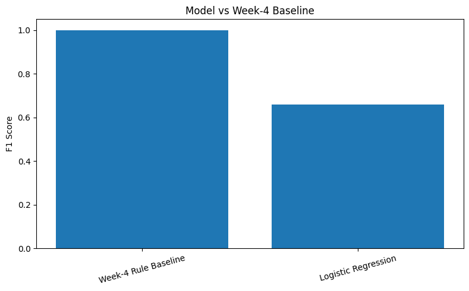

```
Figure saved to:
work/figures/model_vs_baseline_f1.png

Section 7 check passed.
```

```python
# Section 7 — Generate a results chart

import os
import matplotlib.pyplot as plt

FIGURE_DIR = "work/figures"
os.makedirs(FIGURE_DIR, exist_ok=True)

# Plot F1 comparison
plt.figure(figsize=(8, 5))

plt.bar(
    results["Method"],
    results["F1"]
)

plt.ylabel("F1 Score")
plt.title("Model vs Week-4 Baseline")
plt.ylim(0, 1.05)

plt.xticks(rotation=15)
plt.tight_layout()

FIGURE_PATH = os.path.join(
    FIGURE_DIR,
    "model_vs_baseline_f1.png"
)

plt.savefig(
    FIGURE_PATH,
    dpi=150,
    bbox_inches="tight"
)

plt.show()

print("Figure saved to:")
print(FIGURE_PATH)

print("\nSection 7 check passed.")
```

## Self-check

Before you submit, confirm each line honestly:

- Every section above is filled — markdown thinking AND the code that backs it
- The notebook runs top to bottom with no errors (Runtime → Run all)
- No client names, URLs, or private queries anywhere
- My claims use careful words: observed, measured, directional, decision-support
- Committed to my repo under `work/notebooks/` — then submit your repo URL on the card. Done.
- My deployed paper has **all 9 sections** — including the **Abstract** at the top and **Acknowledgments & data credit** (the https://flyrank.ai link) at the bottom.
- **ML-12 done in this notebook's closing cells:** 5-minute demo outline + a social-post cut + a 3-sentence employer-facing summary.